```python
import wkbl
import matplotlib.pyplot as plt
import numpy as np
from matplotlib.colors import LogNorm
import nbody_essentials as nbe
from matplotlib.patches import Circle
```

# Loading a Simulation

```python
#define path to RAMSES snapshot
path = "/data/OWN/Adicora/output_00041"
#load simulation
myhalo = wkbl.Galaxy_Hound(path)
```

```
loading Dark matter..
loading Stars..
loading Gas..
```

# Built-in parametes

the object `myhalo.p` has several values that are typically useful such as

```python
for a in dir(myhalo.p):
    if a[0]=="_":continue
    print(a)
```

```
DelayedCooling
G
H0
Z
aexp
boxlen
cmtopc
file_path
h
kB
k_boltz
kgtoGeV
kpctocm
kpctokm
mH
msuntokg
mu
nener
nml
nmlexist
omegaM
pctocm
rho_crit
scale_T2
scale_d
scale_d_gas
scale_nH
simutoGeVcm3
simutoMsun
simutocm
simutokms
simutokpc
unitd
unitl
unitsimutoMsunkpc3
unitt
```

# Visualize Simulaiton components

```python
# number of pixels
pixels=500
# projection axis
x,y=0,1
edges = np.linspace(0,myhalo.p.boxlen*1000,pixels)
H, xedges, yedges = np.histogram2d(myhalo.dm.pos3d[:,x],
                                   myhalo.dm.pos3d[:,y],
                                   bins=(edges, edges),
                                   weights=myhalo.dm.mass)
fullbox = H.T
# map of the zoom region
zoomreg = np.where(myhalo.dm.mass==myhalo.dm.mass.min())[0]
H, xedges, yedges = np.histogram2d(myhalo.dm.pos3d[zoomreg,x],
                                   myhalo.dm.pos3d[zoomreg,y],
                                   bins=(edges, edges),
                                   weights=myhalo.dm.mass[zoomreg])
fullbox_zoomreg = H.T
```

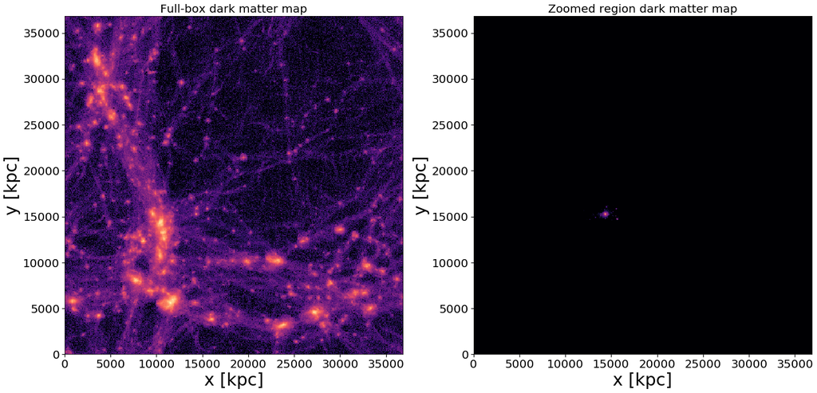

```python
a,b = np.mean(fullbox)*0.1, np.max(fullbox)

fig, [ax,ax1] = plt.subplots(1,2,figsize=[20,10])
# plot map of full box
mass_2 = ax.imshow(fullbox+0.1,interpolation='nearest', origin='low',cmap="magma",
                       extent=[edges[0], edges[-1], edges[0], edges[-1]],
                   norm=LogNorm(vmin=a,vmax=b)
                  )

title = ax.set_title("Full-box dark matter map",fontsize=20)

# plot map of zoom particles



mass_2 = ax1.imshow(fullbox_zoomreg+0.1,interpolation='nearest', origin='low',cmap="magma",
                       extent=[edges[0], edges[-1], edges[0], edges[-1]],
                   norm=LogNorm(vmin=a,vmax=b)
                  )

title = ax1.set_title("Zoomed region dark matter map",fontsize=20)

axis = [ax,ax1]
for a in axis:
    a.set_xlabel("x [kpc]",fontsize=30)
    a.set_ylabel("y [kpc]",fontsize=30)

    a.tick_params(axis='both', which='major', labelsize=20, size=5,width=1.2)
plt.tight_layout()
```

## calculate center

since the stars are only formed in the zoom-region a good first approach to calculate the center of the halo is to compute the center using *shinking sphere* method implemented in the function `nbe.real_center()` using the positions and mass of the stars particles.

```python
center = nbe.real_center(myhalo.st.pos3d, myhalo.st.mass)
print("center--> [x y z] =",center," [kpc]")
```

```
center--> [x y z] = [14314.92184042 15227.63864653 15696.15744377]  [kpc]
```

we can shift the coordinate system of the whole simulation to be centered in `center` using the function `myhalo.center_shift(center)`

```python
myhalo.center_shift(center)
```

and, finally, we can calculate the virial radius of the galaxy using the funcion `myhalo.r_virial()`.  
Notes:  
1) this function not only calculates the virial radius but also also erases all data that is farder than `n` times the final virial radius from the center. This is done to free memory in case of high resolution simulations. the default value of n incase is not explicitely define is `n=2.5`.  
2) if the virial radius is not found inside a limit radius, `r_max`, the procedure will stop at 600 kpc unless a different `r_max` is specified  
3) the galaxy will be rotated to have the disc plane in the `x`-`y` plane unless the `rotate` keyword is set to `False` as in the following example.

```python
myhalo.r_virial(r_max=600,n=2.5,rotate=False)


print("r200 = {0:.2f} kpc".format(myhalo.r200))
```

```
r200 = 211.52 kpc
```

```python
# limit the plot inside n times the r200
n = 2.1
# pixels
pixels = 500
# projection axis
x,y=0,1
edges = np.linspace(-n*myhalo.r200,n*myhalo.r200,pixels)
# dark matter
H, xedges, yedges = np.histogram2d(myhalo.dm.pos3d[:,x],
                                   myhalo.dm.pos3d[:,y],
                                   bins=(edges, edges),
                                   weights=myhalo.dm.mass)
halo = H.T


# stars
H, xedges, yedges = np.histogram2d(myhalo.st.pos3d[:,x],
                                   myhalo.st.pos3d[:,y],
                                   bins=(edges, edges),
                                   weights=myhalo.st.mass)
stars_map = H.T

# gas
H, xedges, yedges = np.histogram2d(myhalo.gs.pos3d[:,x],
                                   myhalo.gs.pos3d[:,y],
                                   bins=(edges, edges),
                                   weights=myhalo.gs.mass)
gas_map = H.T
```

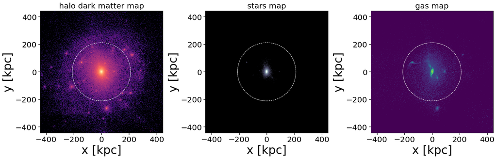

```python
a,b = np.mean(halo)*0.1, np.max(halo)

fig, [ax,ax1,ax2] = plt.subplots(1,3,figsize=[18,6])
# plot map of full box
mass_2 = ax.imshow(halo+0.1,interpolation='nearest', origin='low',cmap="magma",
                       extent=[edges[0], edges[-1], edges[0], edges[-1]],
                   norm=LogNorm(vmin=a,vmax=b)
                  )

title = ax.set_title("halo dark matter map",fontsize=20)


#plot map of stars
mass_2 = ax1.imshow(stars_map+0.1,interpolation='nearest', origin='low',cmap="bone",
                       extent=[edges[0], edges[-1], edges[0], edges[-1]],
                   norm=LogNorm(vmin=a,vmax=b)
                  )

title = ax1.set_title("stars map",fontsize=20)

# plot map of stars

mass_2 = ax2.imshow(gas_map+0.1,interpolation='nearest', origin='low',cmap="viridis",
                       extent=[edges[0], edges[-1], edges[0], edges[-1]],
                   norm=LogNorm(vmin=a,vmax=b)
                  )

title = ax2.set_title("gas map",fontsize=20)




axis = [ax,ax1,ax2]

for a in axis:
    a.set_xlabel("x [kpc]",fontsize=30)
    a.set_ylabel("y [kpc]",fontsize=30)
    circle1 = plt.Circle((0, 0), myhalo.r200, color='w',ls="--",fill=False)
    a.add_artist(circle1)
    a.tick_params(axis='both', which='major', labelsize=20, size=5,width=1.2)
plt.tight_layout()
plt.tight_layout()
```

or make a zoom to see the disc by setting `n=0.2`

```python
# limit the plot inside n times the r200
n = 0.2
# pixels
pixels = 100
# projection axis
x,y=0,1
edges = np.linspace(-n*myhalo.r200,n*myhalo.r200,pixels)
# dark matter
H, xedges, yedges = np.histogram2d(myhalo.dm.pos3d[:,x],
                                   myhalo.dm.pos3d[:,y],
                                   bins=(edges, edges),
                                   weights=myhalo.dm.mass)
halo = H.T


# stars
H, xedges, yedges = np.histogram2d(myhalo.st.pos3d[:,x],
                                   myhalo.st.pos3d[:,y],
                                   bins=(edges, edges),
                                   weights=myhalo.st.mass)
stars_map = H.T

# gas
H, xedges, yedges = np.histogram2d(myhalo.gs.pos3d[:,x],
                                   myhalo.gs.pos3d[:,y],
                                   bins=(edges, edges),
                                   weights=myhalo.gs.mass)
gas_map = H.T
```

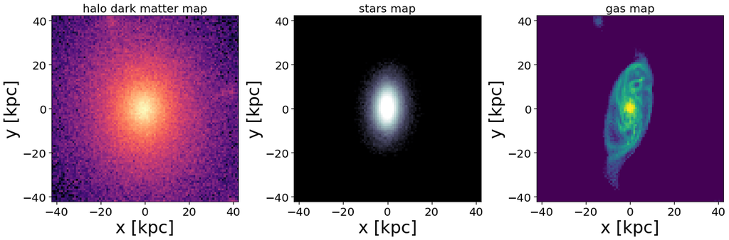

```python
a,b = np.mean(halo)*0.1, np.max(halo)

fig, [ax,ax1,ax2] = plt.subplots(1,3,figsize=[18,6])
# plot map of full box
mass_2 = ax.imshow(halo+0.1,interpolation='nearest', origin='low',cmap="magma",
                       extent=[edges[0], edges[-1], edges[0], edges[-1]],
                   norm=LogNorm(vmin=a,vmax=b)
                  )

title = ax.set_title("halo dark matter map",fontsize=20)


#plot map of stars
mass_2 = ax1.imshow(stars_map+0.1,interpolation='nearest', origin='low',cmap="bone",
                       extent=[edges[0], edges[-1], edges[0], edges[-1]],
                   norm=LogNorm(vmin=a,vmax=b)
                  )

title = ax1.set_title("stars map",fontsize=20)

# plot map of stars

mass_2 = ax2.imshow(gas_map+0.1,interpolation='nearest', origin='low',cmap="viridis",
                       extent=[edges[0], edges[-1], edges[0], edges[-1]],
                   norm=LogNorm(vmin=a,vmax=b)
                  )

title = ax2.set_title("gas map",fontsize=20)




axis = [ax,ax1,ax2]

for a in axis:
    a.set_xlabel("x [kpc]",fontsize=30)
    a.set_ylabel("y [kpc]",fontsize=30)
    circle1 = plt.Circle((0, 0), myhalo.r200, color='w',ls="--",fill=False)
    a.add_artist(circle1)
    a.tick_params(axis='both', which='major', labelsize=20, size=5,width=1.2)
plt.tight_layout()
plt.tight_layout()
```

Now, if we set `rotate=True` or leave it as default the whole box would be rotated to have the disc plane in the x-y plane.

```python
myhalo.r_virial()


print("r200 = {0:.2f} kpc".format(myhalo.r200))
```

```
| Diagonal matrix computed
|    | 19, 0, 0|
| D =| 0, 15, 0|
|    | 0,  0, 4|
r200 = 211.52 kpc
```

the by reploting the last plot we would have the face-on view of the galaxy

```python
# limit the plot inside n times the r200
n = 0.2
# pixels
pixels = 100
# projection axis
x,y=0,1
edges = np.linspace(-n*myhalo.r200,n*myhalo.r200,pixels)
# dark matter
H, xedges, yedges = np.histogram2d(myhalo.dm.pos3d[:,x],
                                   myhalo.dm.pos3d[:,y],
                                   bins=(edges, edges),
                                   weights=myhalo.dm.mass)
halo = H.T


# stars
H, xedges, yedges = np.histogram2d(myhalo.st.pos3d[:,x],
                                   myhalo.st.pos3d[:,y],
                                   bins=(edges, edges),
                                   weights=myhalo.st.mass)
stars_map = H.T

# gas
H, xedges, yedges = np.histogram2d(myhalo.gs.pos3d[:,x],
                                   myhalo.gs.pos3d[:,y],
                                   bins=(edges, edges),
                                   weights=myhalo.gs.mass)
gas_map = H.T
```

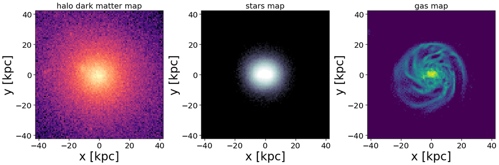

```python
a,b = np.mean(halo)*0.1, np.max(halo)

fig, [ax,ax1,ax2] = plt.subplots(1,3,figsize=[18,6])
# plot map of full box
mass_2 = ax.imshow(halo+0.1,interpolation='nearest', origin='low',cmap="magma",
                       extent=[edges[0], edges[-1], edges[0], edges[-1]],
                   norm=LogNorm(vmin=a,vmax=b)
                  )

title = ax.set_title("halo dark matter map",fontsize=20)


#plot map of stars
mass_2 = ax1.imshow(stars_map+0.1,interpolation='nearest', origin='low',cmap="bone",
                       extent=[edges[0], edges[-1], edges[0], edges[-1]],
                   norm=LogNorm(vmin=a,vmax=b)
                  )

title = ax1.set_title("stars map",fontsize=20)

# plot map of stars

mass_2 = ax2.imshow(gas_map+0.1,interpolation='nearest', origin='low',cmap="viridis",
                       extent=[edges[0], edges[-1], edges[0], edges[-1]],
                   norm=LogNorm(vmin=a,vmax=b)
                  )

title = ax2.set_title("gas map",fontsize=20)




axis = [ax,ax1,ax2]

for a in axis:
    a.set_xlabel("x [kpc]",fontsize=30)
    a.set_ylabel("y [kpc]",fontsize=30)
    circle1 = plt.Circle((0, 0), myhalo.r200, color='w',ls="--",fill=False)
    a.add_artist(circle1)
    a.tick_params(axis='both', which='major', labelsize=20, size=5,width=1.2)
plt.tight_layout()
plt.tight_layout()
```

to have the edge-on view is enought to change the axis with wich the 2D-histogram are built.

```python
# limit the plot inside n times the r200
n = 0.2
# pixels
pixels = 100
# projection axis
x,y=0,2
edges = np.linspace(-n*myhalo.r200,n*myhalo.r200,pixels)
# dark matter
H, xedges, yedges = np.histogram2d(myhalo.dm.pos3d[:,x],
                                   myhalo.dm.pos3d[:,y],
                                   bins=(edges, edges),
                                   weights=myhalo.dm.mass)
halo = H.T


# stars
H, xedges, yedges = np.histogram2d(myhalo.st.pos3d[:,x],
                                   myhalo.st.pos3d[:,y],
                                   bins=(edges, edges),
                                   weights=myhalo.st.mass)
stars_map = H.T

# gas
H, xedges, yedges = np.histogram2d(myhalo.gs.pos3d[:,x],
                                   myhalo.gs.pos3d[:,y],
                                   bins=(edges, edges),
                                   weights=myhalo.gs.mass)
gas_map = H.T
```

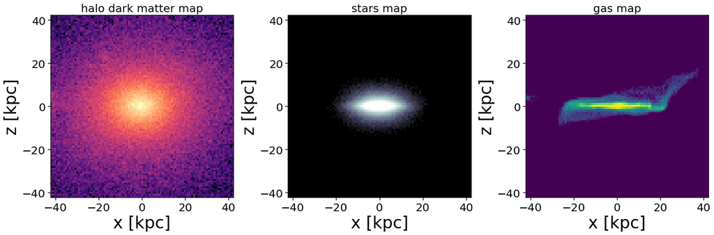

```python
a,b = np.mean(halo)*0.1, np.max(halo)

fig, [ax,ax1,ax2] = plt.subplots(1,3,figsize=[18,6])
# plot map of full box
mass_2 = ax.imshow(halo+0.1,interpolation='nearest', origin='low',cmap="magma",
                       extent=[edges[0], edges[-1], edges[0], edges[-1]],
                   norm=LogNorm(vmin=a,vmax=b)
                  )

title = ax.set_title("halo dark matter map",fontsize=20)


#plot map of stars
mass_2 = ax1.imshow(stars_map+0.1,interpolation='nearest', origin='low',cmap="bone",
                       extent=[edges[0], edges[-1], edges[0], edges[-1]],
                   norm=LogNorm(vmin=a,vmax=b)
                  )

title = ax1.set_title("stars map",fontsize=20)

# plot map of stars

mass_2 = ax2.imshow(gas_map+0.1,interpolation='nearest', origin='low',cmap="viridis",
                       extent=[edges[0], edges[-1], edges[0], edges[-1]],
                   norm=LogNorm(vmin=a,vmax=b)
                  )

title = ax2.set_title("gas map",fontsize=20)




axis = [ax,ax1,ax2]

for a in axis:
    a.set_xlabel("x [kpc]",fontsize=30)
    a.set_ylabel("z [kpc]",fontsize=30)
    circle1 = plt.Circle((0, 0), myhalo.r200, color='w',ls="--",fill=False)
    a.add_artist(circle1)
    a.tick_params(axis='both', which='major', labelsize=20, size=5,width=1.2)
plt.tight_layout()
plt.tight_layout()
```